## ADA HW5

## Minqian Guo(mg3418)

**Prob a. Fit a multiple linear regression model**

```r
require(MASS)
data <- Pima.te
fit <- lm(glu~npreg+bp+skin+bmi+age,data=data)
summary(fit)
```

```
##
## Call:
## lm(formula = glu ~ npreg + bp + skin + bmi + age, data = data)
##
## Residuals:
##    Min     1Q Median     3Q    Max
## -61.29 -20.56  -4.36  17.37  76.51
##
## Coefficients:
##             Estimate Std. Error t value Pr(>|t|)
## (Intercept)   56.831     10.309    5.51  7.2e-08 ***
## npreg         -0.875      0.647   -1.35  0.17735
## bp             0.104      0.138    0.75  0.45353
## skin           0.263      0.216    1.21  0.22575
## bmi            0.796      0.302    2.64  0.00880 **
## age            0.764      0.207    3.69  0.00026 ***
## ---
## Signif. codes:  0 '***' 0.001 '**' 0.01 '*' 0.05 '.' 0.1 ' ' 1
##
## Residual standard error: 28.6 on 326 degrees of freedom
## Multiple R-squared:  0.134,  Adjusted R-squared:  0.121
## F-statistic: 10.1 on 5 and 326 DF,  p-value: 5.58e-09
```

**Prob b. The underlying assumptions check**

1. Nonlinearity: Using R-squared value in the result of linear regression.

```r
summary(fit)$r.squared
```

```
## [1] 0.1338
```

Since the R-squared is small, which means the lack of fit of fitted model.

2. Normality

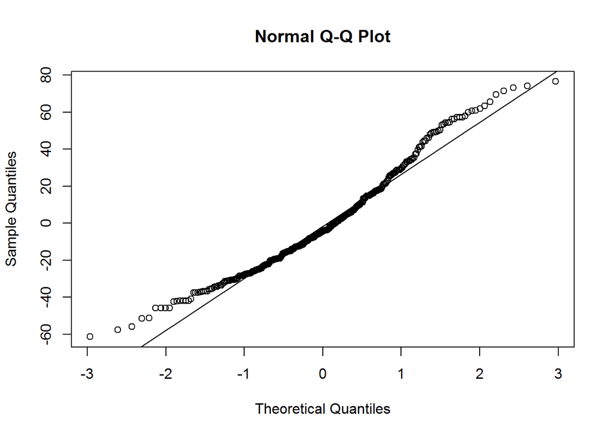

```r
qqnorm(fit$residuals)
qqline(fit$residuals)
```

The QQ plot shows the assumption of normality is invalid.

```r
shapiro.test(fit$residuals)
```

```
##
##  Shapiro-Wilk normality test
##
## data:  fit$residuals
## W = 0.9703, p-value = 2.532e-06
```

```r
shapiro.test(fit$residuals)$p.value
```

```
## [1] 2.532e-06
```

3. Homoscedasticity

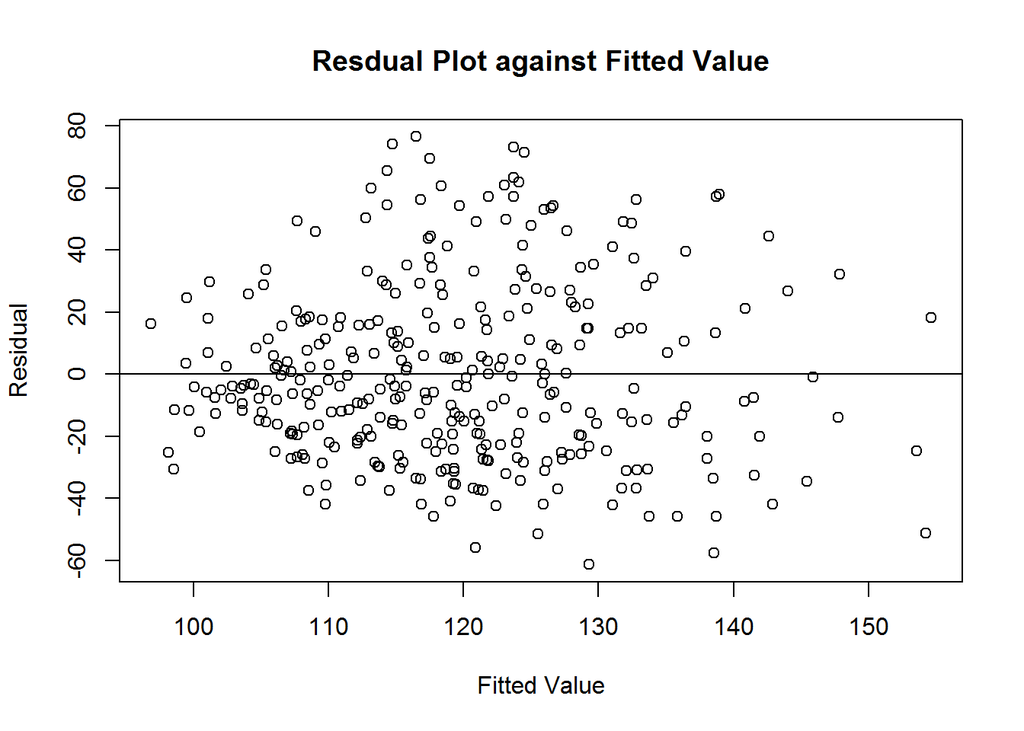

```r
plot(fit$fitted.values,fit$residuals,xlab='Fitted Value',ylab='Residual',main="Resdual Plot against Fitted Value")
abline(h=0)
```

The plot of the residuals against the fitted values shows a scatter plot without certian pattern. Thus the assumption of constant error is valid.

4. Uncorrelation of Error

```r
require(lmtest)
dwtest(fit)
```

```
##
##  Durbin-Watson test
##
## data:  fit
## DW = 1.938, p-value = 0.2847
## alternative hypothesis: true autocorrelation is greater than 0
```

```r
dwtest(fit)$p.value
```

```
## [1] 0.2847
```

By using Durbin-watson test to do correlation check of error, Since p-value is greater than 0.05, we should accept the null hypothesis. So, the assumption of uncorrelated error is valid.

6.. Influential Points

```r
lmi <- lm.influence(fit)
lms <- summary(fit)
e <- resid(fit)
s <- lms$sigma
si <- lmi$sigma
xxi <- diag(lms$cov.unscaled)
h <- lmi$hat
bi <- coef(fit)-t(coef(lmi))
dfbetas <- bi/t(si%o%xxi^0.5)
stand.resid <- e/(si*(1-h)^0.5)
DFFITS <- h^0.5*e/(si*(1-h))
which(abs(stand.resid)>2*sqrt(6/332))
```

[output not shown]

**Prob c. The remedial measures in case of violations of any of the underlying assumptions**

1. Nonlinearity:

Simple trasformations, e.g, take log

Non-linear model

Other predictors

2. Non-Normality:

Transformation

Robust regression methods

3. Influential points:

Robust regression